# Selected Sections from Chapter 9: 9.6

© Scott Robison 2021 all rights reserved.

## 9.6 The Method of Moments

> Start by [Reading](https://github.com/chqngh-berkeley/personal/blob/master/Mathematical%20Statistics%20-%207th%20Edition%20-%20Wackerly.pdf) pages 472-475 from the text.

**Using Moments to Estimate Parameters**

In this section, we will discuss one of the oldest methods for deriving point estimators: the method of moments. Later we will move on to a more sophisticated method, the method of maximum likelihood. The method of moments is a very simple procedure for finding an estimator for one or more population parameters.

In short, the method of moments involves equating sample moments with theoretical moments. So, let’s start by making sure we recall the definitions of theoretical moments, as well as learn the definitions of sample moments.

Definitions.

1. $\mu^{'}=E(X^k)$ is the $k$th (theoretical) moment of the distribution (about the origin), for $k = 1,2,...$
2. $\mu^*=E[(X-\mu)^k]$ is the $k$th (theoretical) moment of the distribution (about the mean), $for k = 1,2,...$
3. $M_k^{'}=\frac{1}{n} \sum_{i=1}^n X_i^k$ is the $k$th sample moment, for $k = 1,2,...$
4. $M_k^*=\frac{1}{n} \sum_{i=1}^n(X_i-\overline{X})^k$ is the $k$th sample moment about the mean, for $k = 1,2,...$

**One Form of the Method**

The basic idea behind this form of the method is to:

1. Equate the first sample moment about the origin $M_1^{'}=\frac{1}{n} \sum_{i=1}^nX_i^1=\overline{X}$ to the first theoretical moment $E(X)$.
2. Equate the second sample moment about the origin $M_2^{'}=\frac{1}{n} \sum_{i=1}^nX_i^2$ to the second theoretical moment $E(X^2)$.
3. Continue equating sample moments about the origin, $M_k^{'}$, with the corresponding theoretical moments $E(X^k$),$k = 3,4,...$ until you have as many equations as you have parameters.
4. Solve for the parameters.

The resulting values are called method of moments estimators. It seems reasonable that this method would provide good estimates, since the empirical distribution converges in some sense to the probability distribution. Therefore, the corresponding moments should be about equal.

ex. Fit a normal curve to sample data taken from Normal Dist.

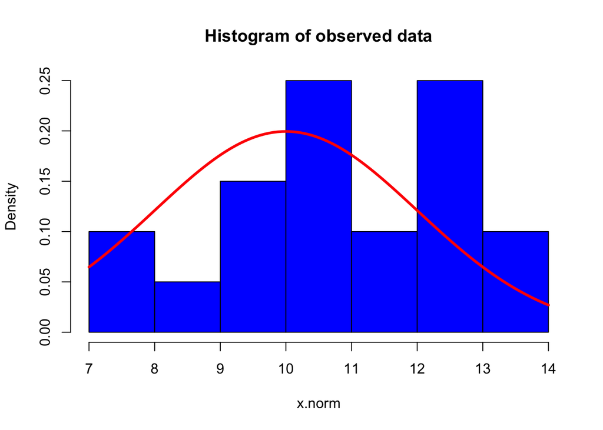

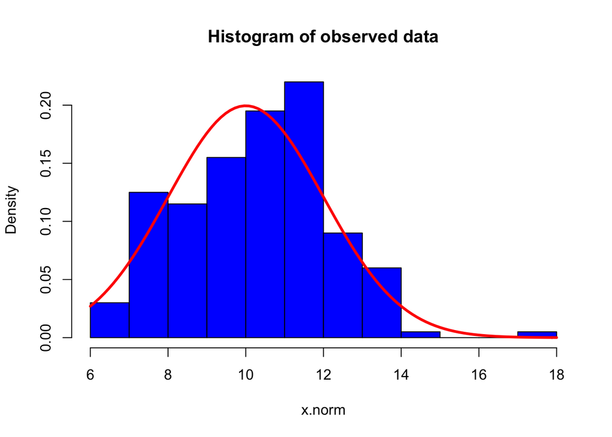

### Example 1

Let $X_1,X_2,…,X_n$ be Bernoulli random variables with parameter $p$. What is the method of moments estimator of $p$?

### Solution

[video not shown]

### Example 2

$X_1,X_2,…,X_n$ be normal random variables with mean $\mu$ and variance $\sigma^2$. What are the method of moments estimators of the mean $\mu$ and variance $\sigma^2$?

### Solution

Please try this on your own before looking at the [solution](https://people.ucalgary.ca/~sarobiso/323/text%20soltutions/MoM%20ex2.pdf)

### Example 3

Use the method of moments to estimate $c$ and $\theta$ in the two-parameter uniform density:

$$f(x)=\frac{1}{2\theta},c-\theta<x<c+\theta$$

### Solution

[video not shown]

**Another Form of the Method**

The basic idea behind this form of the method is to:

1. Equate the first sample moment about the origin $M_1^{'}=\frac{1}{n} \sum_{i=1}^nX_i^1=\overline{X}$ to the first theoretical moment $E(X)$.
2. Equate the second sample moment about the mean $M_2^{*}=\frac{1}{n} \sum_{i=1}^n(X_i-\overline{X})^2$ to the second theoretical moment about the mean $E[(X-\mu)^2]$
3. Continue equating sample moments about the mean $M_k^*$ with the corresponding theoretical moments about the mean $E[(X-\mu)^k]$ , $k = 3,4,…$ until you have as many equations as you have parameters.
4. Solve for the parameters.

Again, the resulting values are called **method of moments estimators**.

### Example 4

$X_1,X_2,…,X_n$ be gamma random variables with mean $\alpha\beta$. What are the method of moments estimators $\alpha$ and $\beta$?

### Solution

Please try this on your own before looking at the [solution](https://people.ucalgary.ca/~sarobiso/323/text%20soltutions/MoM%20ex%204.pdf)

### Example 5

recall example 2: $X_1,X_2,…,X_n$ be normal random variables with mean $\mu$ and variance $\sigma^2$. What are the method of moments estimators of the mean $\mu$ and variance $\sigma^2$?

### Solution

[video not shown]

> Please [**Practice**](https://github.com/chqngh-berkeley/personal/blob/master/Mathematical%20Statistics%20-%207th%20Edition%20-%20Wackerly.pdf) as many exercises from pages 475-476 as possible the odd questions have answers in the back of the text.

> This is where the real learning happens.